# Cross-Validation

Lecture 18

March 6, 2026

# Last Class

## Bias vs. Variance

- **Bias** is error from mismatches between the model predictions and the data ($\text{Bias}[\hat{f}] = \mathbb{E}[\hat{f}] - y$).
- **Variance** is error from over-sensitivity to small fluctuations in training inputs $D$ ($\text{Variance} = \text{Var}_D(\hat{f}(x; D)$).

Commonly discussed in terms of “bias-variance tradeoff”: more valuable to think of these as contributors to total error.

## Overfitting and Underfitting

- **Underfitting**: Model predicts individual data points poorly, high bias, think approximation error
- **Overfitting**: Model generalizes poorly, high variance, think estimation error.

## Model Degrees of Freedom

Potential to overfit vs. underfit isn’t directly related to standard metrics of “model complexity” (number of parameters, etc).

Instead, think of **degrees of freedom**: how much flexibility is there given the model parameterization to “chase” reduced model error?

## Regularization

Can reduce degrees of freedom with **regularization** (shrinkage of estimates (*e.g.* LASSO) vs. “raw” MLE) or **dimensionality reduction** (model simplification).

[figure not shown]

Regularization Meme

Source: Richard McElreath

# Cross-Validation

## Can We Drive Model Error to Zero?

Effectively, no. **Why**?

- Inherent noise: even a perfect model wouldn’t perfectly predict observations.
- Model mis-specification (the cause of bias)
- Model estimation is never “right” (the cause of variance)

## Quantifying Generalization Error

The goal is then to minimize the generalized (expected) error:

$$\mathbb{E}\left[L(X, \theta)\right] = \int_X L(x, \theta) \pi(x)dx$$

where $L(x, \theta)$ is an error function capturing the discrepancy between $\hat{f}(x, \theta)$ and $y$.

## In-Sample Error

Since we don’t know the “true” distribution of $y$, we usually try to approximate it using the training data:

$$\hat{L} = \min_{\theta \in \Theta} L(x_n, \theta)$$

But: **This is minimizing in-sample error and is likely to result an optimistic score.**

## Held Out Data

Instead, let’s divide our data into a training dataset $y_k$ and testing dataset $\tilde{y}_l$.

1. Fit the model to $y_k$;
2. Evaluate error on $\tilde{y}_l$.

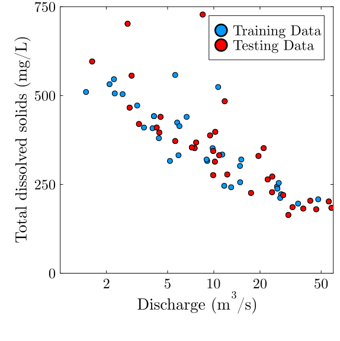

Figure 1: Data for CV example.

## Held Out Data

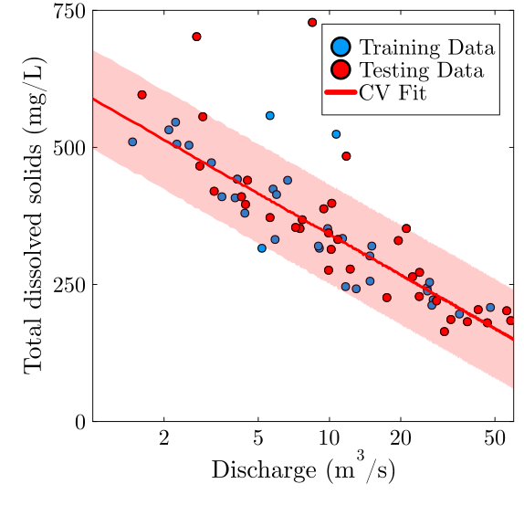

Figure 2: Data for CV example.

**Testing Data MSE**: 7498.4

**Testing Data Score**: 7498.4

## $k$-Fold Cross-Validation

What if we repeated this procedure for multiple held-out sets?

1. Randomly split data into $k = n / m$ equally-sized subsets.
2. For each $i = 1, \ldots, k$, fit model to $y_{-i}$ and test on $y_i$.

If data are large, this is a good approximation.

## Random Division of Data

**Why do we want to randomly divide the data and test over all splits?**

## Consistency of C-V

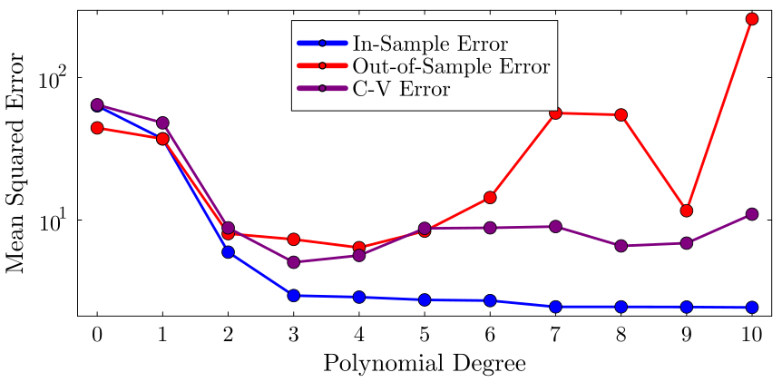

Figure 3: Impact of increasing model complexity on model fits

```julia
# create data set
Random.seed!(1)
ntrain = 20
x = rand(Uniform(-2, 2), ntrain)
f(x) = x.^3 .- 5x.^2 .+ 1
y = f(x) + rand(Normal(0, 2), length(x))

# function to fit polynomial model
function polyfit(d, x, y)
    function m(d, θ, x)
        mout = zeros(length(x), d + 1)
        for j in eachindex(x)
            for i = 0:d
                mout[j, i + 1] = θ[i + 1] * x[j]^i
            end
        end
        return sum(mout; dims=2)
    end
    θ₀ = [zeros(d+1); 1.0]
    lb = [-10.0 .+ zeros(d+1); 0.01]
    ub = [10.0 .+ zeros(d+1); 20.0]
    optim_out = optimize(θ -> -sum(logpdf.(Normal.(m(d, θ[1:end-1], x), θ[end]), y)), lb, ub, θ₀)
    θmin = optim_out.minimizer
    mfit(x) = sum([θmin[i + 1] * x^i for i in 0:d])
    return (mfit, θmin[end])
end

# create out-of-sample data for testing generalizability
ntest = 20
xtest = rand(Uniform(-2, 2), ntest)
ytest = f(xtest) + rand(Normal(0, 2), length(xtest))

# calculate cross-validation fits and scores
function cv_poly(d, x, y, nfolds=5)
    # split data into folds
    labels = repeat(1:nfolds, outer=Int(length(x) / nfolds))
    fold_labels = shuffle(labels) # randomly permute the labels
    # do C-V
    cv_error = zeros(nfolds)
    for fold in 1:nfolds
        test_idx = findall(fold_labels .== fold)
        train_idx = setdiff(1:length(x), test_idx)
        m, σ = polyfit(d, x[train_idx], y[train_idx])
        cv_error[fold] = mean((m.(x[test_idx]) .- y[test_idx]).^2)
    end
    return cv_error
end

in_error = zeros(11)
out_error = zeros(11)
cv_error = zeros(11)
nfold = 4
#calculate sum of squared errors
for d = 0:10
    m, σ = polyfit(d, x, y)
    in_error[d+1] = mean((m.(x) .- y).^2)
    out_error[d+1] = mean((m.(xtest) .- ytest).^2)
    cv_error[d+1] = mean(cv_poly(d, x, y, nfold))
end

plot(0:10, in_error, marker=(:circle, :blue, 8), line=(:blue, 3), label="In-Sample Error", xlabel="Polynomial Degree", ylabel="Mean Squared Error", legend=:top)
plot!(0:10, out_error, marker=(:circle, :red, 8), line=(:red, 3), label="Out-of-Sample Error")
plot!(0:10, cv_error, marker=(:circle, :purple, 8), line=(:purple, 3), label="C-V Error")
plot!(yaxis=:log)
plot!(xticks=0:1:10)
plot!(size=(900, 450))
```

## Leave-One-Out Cross-Validation (LOO-CV)

The problem with $k$-fold CV, when data is scarce, is withholding $n/k$ points, which results in more biased estimates.

**LOO-CV**: Set $k=n$

**The trouble**: estimates of $L$ are highly correlated since every two datasets share $n-2$ points.

**The benefit**: LOO-CV approximates seeing “the next datum”.

## LOO-CV Algorithm

We focus here on the log score, but any error metric can be used.

1. Drop one value $y_i$.
2. Refit model on rest of data $y_{-i}$.
3. Predict dropped point $p(\hat{y}_i | y_{-i})$.
4. Evaluate score on dropped point ($-\log p(y_i | y_{-i})$).
5. Repeat on rest of data set.

## LOO-CV Example

**Model**:
$$D \rightarrow S \ {\color{purple}\leftarrow U}$$
$$S = f(D, U)$$

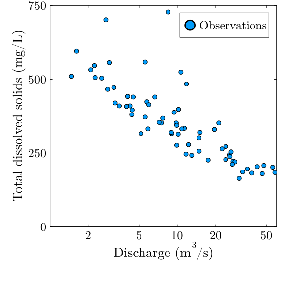

Figure 4: Data for CV example.

## LOO-CV Flow

1. **Drop one value $y_i$**.
2. Refit model on $y_{-i}$.
3. Predict $p(\hat{y}_i | y_{-i})$.
4. Evaluate $-\log p(y_i | y_{-i})$.
5. Repeat on rest of data set.

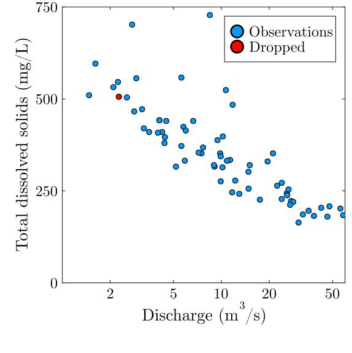

Figure 5: Data for CV example.

## LOO-CV Flow

1. Drop one value $y_i$.
2. **Refit model on $y_{-i}$**.
3. **Predict $p(\hat{y}_i | y_{-i})$**.
4. Evaluate $-\log p(y_i | y_{-i})$.
5. Repeat on rest of data set.

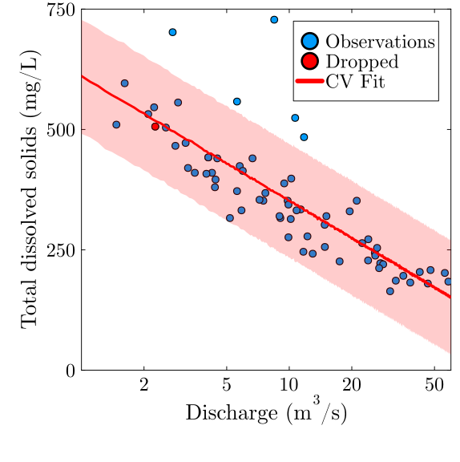

Figure 6: Data for CV example.

## LOO-CV Flow

1. Drop one value $y_i$.
2. Refit model on $y_{-i}$.
3. Predict $p(\hat{y}_i | y_{-i})$.
4. **Evaluate $-\log p(y_i | y_{-i})$**.
5. Repeat on rest of data set.

**Out of Sample**:

$p(y_i | y_{-i})$ = 5.2

**In Sample**:

$p(y_{-i} | y_{-i})$ = 5.7

## LOO-CV Flow

1. Drop one value $y_i$.
2. Refit model on $y_{-i}$.
3. Predict $p(\hat{y}_i | y_{-i})$.
4. Evaluate $-\log p(y_i | y_{-i})$.
5. **Repeat on rest of data set**.

**LOO-CV Score**: 5.8

This is the **average log-likelihood of out-of-sample data**.

## Leave-$k$-Out Cross-Validation

Drop $k$ values, refit model on rest of data, check for predictive skill.

As $k \to n$, this reduces to the prior predictive distribution
$$p(y^{\text{rep}}) = \int_{\theta} p(y^{\text{rep}} | \theta) p(\theta) d\theta.$$

## Challenges with Cross-Validation

- This can be very computationally expensive!
- We often don’t have a lot of data for calibration, so holding some back can be a problem.
- Best score still be over-optimistic.
- Can fail if you try to compare too many different models.

## C-V and Feature Selection

Every step of model “tuning” must be subject to C-V: this includes any statistical feature selection.

In other words: construct held-out data sets, then do feature selection + model training + evaluation **all at once** for each fold.

Otherwise the C-V evaluation is biased by the “full knowledge” of which features to use.

# Cross-Validation for Dependent Data

## Challenges with C-V With Structured Data

- Data structure creates dependencies: holding out a random subset of data might not align properly.
- **Example**: What if we randomly hold out data in the middle of a time series?

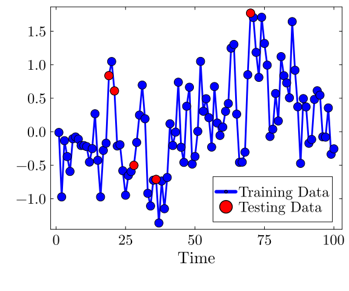

Figure 7

```julia
μ = 0.01
ρ = 0.7
σ = 0.5
ar_var = sqrt(σ^2 / (1 - ρ^2))
T = 100
ts_stat = zeros(T)
for i = 1:T
    if i == 1
        ts_stat[i] = rand(Normal(0, ar_var))
    else
        ts_stat[i] = ρ * ts_stat[i-1] + rand(Normal(0, σ))
    end
end

p = plot(1:T, ts_stat, marker=:circle, markersize=8, color=:blue, label="Training Data", xlabel="Time", linewidth=3, size=(600, 500))
p1 = deepcopy(p)
test_idx1 = sample(1:nrow(tds), 5, replace=false)
scatter!(p1, test_idx1, ts_stat[test_idx1], color=:red, markersize=8, label="Testing Data")
```

## TS Approach: Leave-Future-Out C-V

**Idea**: Use model fit on data $\{y_1, \ldots, y_i\}$ and predict $y_{i+1}$

Can also look at multi-step prediction: predict $y_{i+h}$ for some forecast horizon $h$.

## LFO-CV Example

1. Set minimum length $m$.
2. **Refit model on $\{y_1, y_m\}$**.
3. **Predict $p(\hat{y}_{m+1} | y_{1:m})$**.
4. **Evaluate $-\log p(y_{m+1} | y_{1:m})$**
5. Increment $m$ by 1 and repeat until end is hit.
6. Take mean of individual scores.

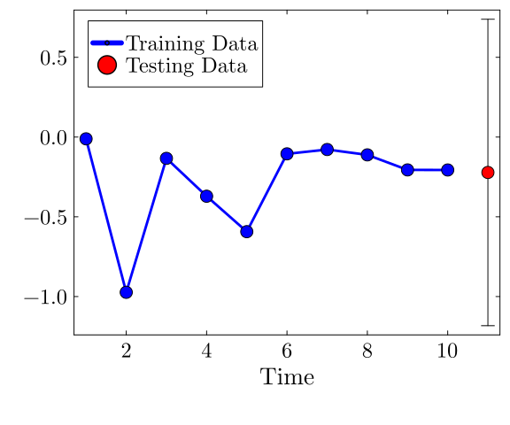

Figure 8

```julia
function cv_lfo(dat, m)
    ts_pred = zeros(length(dat) - m, 10_000)
    log_p = zeros(length(dat) - m)
    function ar1_loglik_whitened(θ, dat)
        # might need to include mean or trend parameters as well
        # subtract trend from data to make this mean-zero in this case
        α, ρ, σ = θ
        T = length(dat)
        ll = 0 # initialize log-likelihood counter
        for i = 1:T
            if i == 1
                ll += logpdf(Normal(α / (1 - ρ), sqrt(σ^2 / (1 - ρ^2))), dat[i])
            else
                r = dat[i] - (α + ρ * dat[i-1])
                ll += logpdf(Normal(0, σ), r)
            end
        end
        return ll
    end

    lb = [-5.0, -0.99, 0.01]
    ub = [5.0, 0.99, 5]
    init = [0.0, 0.6, 0.3]

    for i = (m+1):T
        optim_whitened = Optim.optimize(θ -> -ar1_loglik_whitened(θ, dat[1:(i-1)]), lb, ub, init)
        θ = optim_whitened.minimizer
        # get log score of data
        log_p[i - m] = -logpdf(Normal(θ[1] .+ θ[2] * dat[i-1], θ[3]), dat[i])
        # simulate predictions
        ts_pred[i - m, :] = θ[1] .+ θ[2] * dat[i-1] .+ rand(Normal(0, θ[3]), 10_000)

    end
    return (log_p, ts_pred)
end

m = 10
log_p, ts_lfo = cv_lfo(ts_stat, m)
p = plot(1:m, ts_stat[1:m], marker=:circle, markersize=8, color=:blue, label="Training Data", xlabel="Time", linewidth=3, size=(600, 500))
pred_quantile = quantile(ts_lfo[1, :], [0.05, 0.95])
scatter!(p, [m+1], [ts_stat[m+1]], yerr = pred_quantile .+ ts_stat[m+1], marker=:circle, markersize=8, color=:red, label="Testing Data")
```

## LFO-CV Example

1. Set minimum length $m$.
2. Refit model on $\{y_1, y_m\}$.
3. Predict $p(\hat{y}_{m+1} | y_{1:m})$.
4. Evaluate $-\log p(y_{m+1} | y_{1:m})$
5. **Increment $m$ by 1 and repeat until end is hit**.
6. Take mean of individual scores.

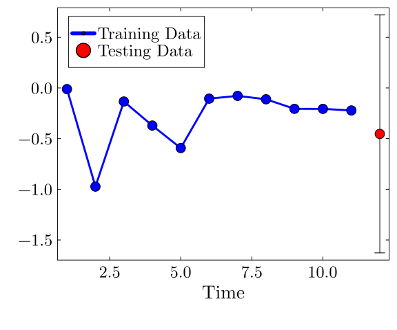

Figure 9

```julia
i = m + 1
p = plot(1:i, ts_stat[1:i], marker=:circle, markersize=8, color=:blue, label="Training Data", xlabel="Time", linewidth=3, size=(600, 500))
pred_quantile = quantile(ts_lfo[i - m + 1, :], [0.05, 0.95])
scatter!(p, [i+1], [ts_stat[i+1]], yerr = pred_quantile .+ ts_stat[i+1], marker=:circle, markersize=8, color=:red, label="Testing Data")
```

## LFO-CV Example

1. Set minimum length $m$.
2. Refit model on $\{y_1, y_m\}$.
3. Predict $p(\hat{y}_{m+1} | y_{1:m})$.
4. Evaluate $-\log p(y_{m+1} | y_{1:m})$
5. Increment $m$ by 1 and repeat until end is hit.
6. **Take mean of individual scores**.

**LFO-CV score**: 0.9

# Key Points and Upcoming Schedule

## Key Points (Cross-Validation)

- Hold out data (one or more points) randomly, refit model, and quantify predictive skill.
- LOO-CV maximizes use of data but can be computationally expensive.
- Be thoughtful about “blocking” for structured data to avoid information leakage.
- **All parts of statistical modeling must be included in C-V workflow**.

## Next Classes

**Monday**: Hypothesis Testing

## Assessments

**HW3**: Due today.

# References